# Predictive Modeling

November 4, 2016

## Overview

- Linear Modeling Techniques:
  - shrinkage
  - dimensionality reduction
- Motivation:
  - less overfitting
  - lower variance (at cost of bias)
  - curse of dimensionality

## Ridge and Lasso: Shrinkage

- Ridge regression: \[\sum_{i = 1}^{n}(y_{i} - \beta_{0} - \sum_{j = 1}^{p}\beta_{j}x_{ij})^{2} + \lambda \sum_{j=1}^p \beta_j^2\]
- Lasso regression: \[\sum_{i = 1}^{n}(y_{i} - \beta_{0} - \sum_{j = 1}^{p}\beta_{j}x_{ij})^{2} + \lambda \sum_{j=1}^p |\beta_j|\]
- \(\lambda\) controls the amount of penalty assigned to non-zero coefficients, encourage shrinkage

## Ridge vs. Lasso

Lasso encourages feature-*selection*, while ridge produces more non-zero coefficients.

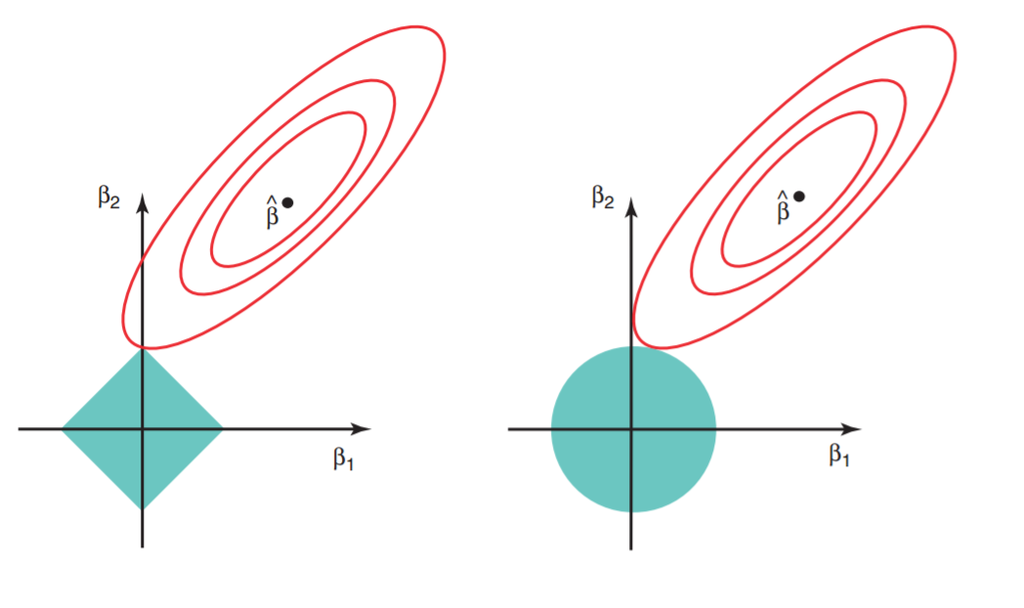

From: An Introduction to Statistical Learning, by James et al

## PCR and PLSR: Dimensionality Reduction

Purpose: reduce number of predictors by creating new ones from linear combination of the original

- PCR: principal component regression
  - unsupervised
  - choose direction that captures most variance in predictors
- PLSR: partial least square regression
  - supervised
  - choose direction that captures most variance in predictors AND response variable

## Dataset

Given 400 bank customers and their personal information, try to predict *Balance*

- Income
- Limit
- Rating
- Cards
- Age
- Education
- Gender
- Student
- Married
- Ethnicity

http://www-bcf.usc.edu/~gareth/ISL/Credit.csv

## Dataset

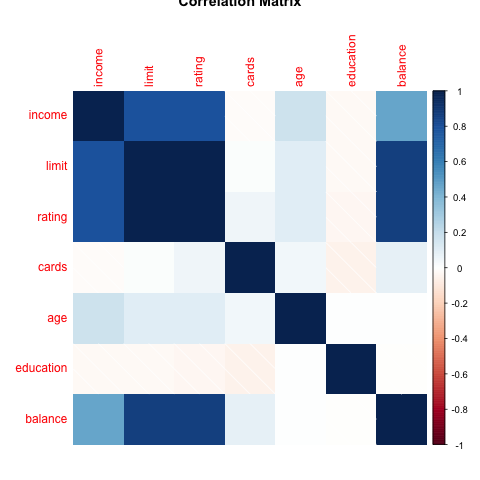

Correlation Matrix

## Model Results: Cross-Validation

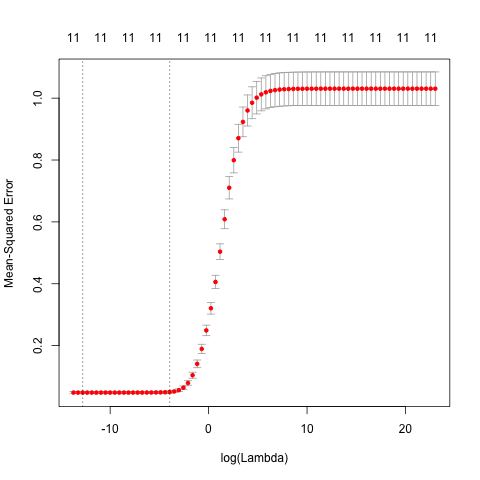

Ridge Regression

## Model Results: Coefficients

|  | ols | ridge | lasso | pcr | plsr |
| --- | --- | --- | --- | --- | --- |
| (Intercept) | 0.000 |  |  |  |  |
| Age | -0.023 | -0.023 | -0.023 | -0.023 | -0.023 |
| Cards | 0.053 | 0.056 | 0.053 | 0.053 | 0.052 |
| Education | -0.007 | -0.008 | -0.007 | -0.007 | -0.008 |
| EthnicityAsian | 0.016 | 0.016 | 0.016 | 0.016 | 0.016 |
| EthnicityCaucasian | 0.011 | 0.011 | 0.011 | 0.011 | 0.011 |
| GenderFemale | -0.012 | -0.012 | -0.012 | -0.012 | -0.012 |
| Income | -0.598 | -0.598 | -0.597 | -0.598 | -0.598 |
| Limit | 0.958 | 1.031 | 0.966 | 0.958 | 0.958 |
| MarriedYes | -0.009 | -0.009 | -0.009 | -0.009 | -0.009 |
| Rating | 0.382 | 0.310 | 0.374 | 0.382 | 0.383 |
| StudentYes | 0.278 | 0.279 | 0.278 | 0.278 | 0.278 |

## Model Results: Error

|  | MSE |
| --- | --- |
| ols : | 0.0448 |
| ridge : | 0.0458 |
| lasso : | 0.0457 |
| pcr : | 0.0463 |
| plsr : | 0.0463 |

OLS has the least test error, though they're all pretty close